# Class Stats

Wulfph

5/13/2021

# Data on C212:

```r
library(tidyverse)
#Read in the data
data <- na.omit(as_tibble(read.csv("gradedist.csv")))
data$AVG.SECT.GPA <- as.double(data$AVG.SECT.GPA)
data$AVG.STDNT.CUM.GPA <- as.double(data$AVG.STDNT.CUM.GPA)
data
```

```
## # A tibble: 80 x 44
##    TERM.DESCRIPTION TERM  SESSION SESSION.DESCRIPTION  DEPARTMENT SUBJECT COURSE
##    <chr>            <chr> <chr>   <chr>                <chr>      <chr>    <int>
##  1 Fall 2020        4208  1       Regular Academic Se~ CSCI       CSCI-C     212
##  2 Summer 2020      4205  6W1     Six Week - First     CSCI       CSCI-C     212
##  3 Spring 2020      4202  1       Regular Academic Se~ CSCI       CSCI-C     212
##  4 Spring 2020      4202  1       Regular Academic Se~ CSCI       CSCI-C     212
##  5 Spring 2020      4202  1       Regular Academic Se~ CSCI       CSCI-H     212
##  6 Fall 2019        4198  1       Regular Academic Se~ CSCI       CSCI-C     212
##  7 Summer 2019      4195  6W1     Six Week - First     CSCI       CSCI-C     212
##  8 Spring 2019      4192  1       Regular Academic Se~ CSCI       CSCI-C     212
##  9 Spring 2019      4192  1       Regular Academic Se~ CSCI       CSCI-C     212
## 10 Spring 2019      4192  1       Regular Academic Se~ CSCI       CSCI-H     212
## # ... with 70 more rows, and 37 more variables: CLASS.SECTION.NBR <int>,
## #   COURSE.DESCRIPTION <chr>, INSTRUCTOR.NAME <chr>, GPA.GRADES <int>,
## #   TOTAL.GRADES <int>, AVG.SECT.GPA <dbl>, AVG.STDNT.CUM.GPA <dbl>,
## #   PERCENT.MAJORS <dbl>, PA <dbl>, PB <dbl>, PC <dbl>, PD <dbl>,
## #   OTHER.GRADES <int>, A. <int>, A <int>, A..1 <int>, B. <int>, B <int>,
## #   B..1 <int>, C. <int>, C <int>, C..1 <int>, D. <int>, D <int>, D..1 <int>,
## #   F <int>, W <int>, WX <int>, I <int>, R <int>, P <int>, S <int>, NY <int>,
## #   NR <int>, NC <int>, OTHER <int>, EFFECTIVE.DATE <chr>
```

## Is the Data Normal?

So this is a question that basically means is the data for the things we care about fairly linear. It should look like a roughly y=x+whatever line. Surpisingly, it appears the data for our distribution of classes who have taken C212 is fairly normal. This means our math should be fairly easy.

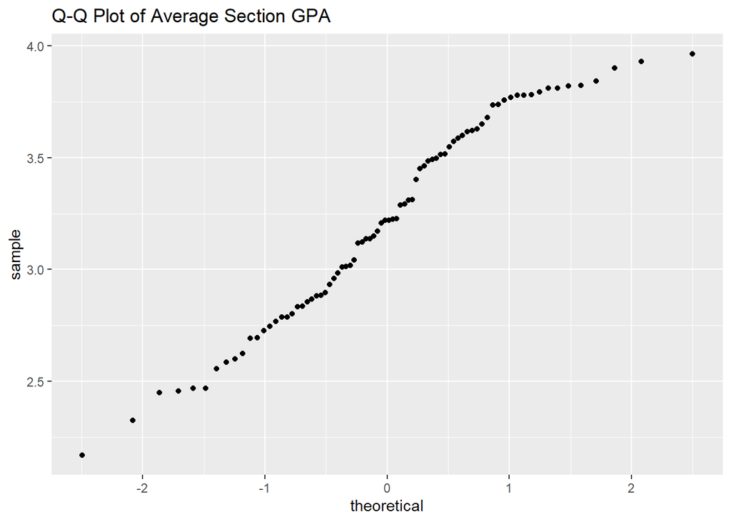

```r
ggplot(data, aes(sample = AVG.SECT.GPA)) + stat_qq() + ggtitle("Q-Q Plot of Average Section GPA")
```

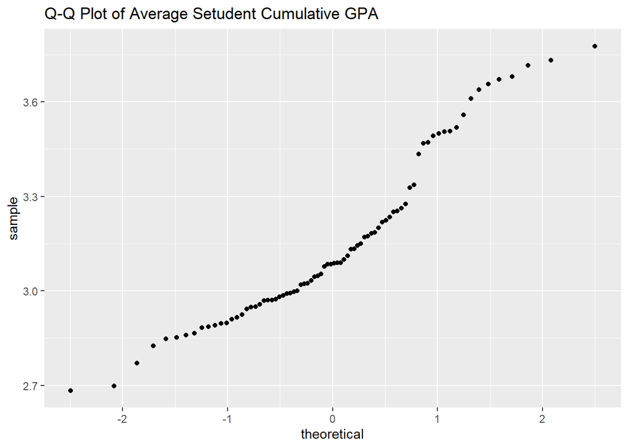

```r
ggplot(data, aes(sample = AVG.STDNT.CUM.GPA)) + stat_qq() + ggtitle("Q-Q Plot of Average Setudent Cumulative GPA")
```

Let’s talk about the two main values we will be inspecting. The first is the “Average Section GPA.” This value is self-descriptive and should be treated as the mean grade of students in the class in a sense. The second value is “Average Student Cumulative GPA,” which is a fancy way of saying the mean GPA of students taking the class.

```r
teacher_list <- split(data, data$INSTRUCTOR.NAME)
teacher_list
```

```
## $`Bhutta,Adeel A`
## # A tibble: 11 x 44
##    TERM.DESCRIPTION TERM  SESSION SESSION.DESCRIPTION  DEPARTMENT SUBJECT COURSE
##    <chr>            <chr> <chr>   <chr>                <chr>      <chr>    <int>
##  1 Summer 2020      4205  6W1     Six Week - First     CSCI       CSCI-C     212
##  2 Spring 2020      4202  1       Regular Academic Se~ CSCI       CSCI-C     212
##  3 Spring 2020      4202  1       Regular Academic Se~ CSCI       CSCI-C     212
##  4 Spring 2019      4192  1       Regular Academic Se~ CSCI       CSCI-C     212
##  5 Spring 2019      4192  1       Regular Academic Se~ CSCI       CSCI-C     212
##  6 Fall 2018        4188  1       Regular Academic Se~ CSCI       CSCI-H     212
##  7 Spring 2018      4182  1       Regular Academic Se~ CSCI       CSCI-C     212
##  8 Spring 2018      4182  1       Regular Academic Se~ CSCI       CSCI-C     212
##  9 Spring 2017      4172  1       Regular Academic Se~ CSCI       CSCI-C     212
## 10 Spring 2017      4172  1       Regular Academic Se~ CSCI       CSCI-C     212
## 11 Fall 2016        4168  1       Regular Academic Se~ CSCI       CSCI-H     212
## # ... with 37 more variables: CLASS.SECTION.NBR <int>,
## #   COURSE.DESCRIPTION <chr>, INSTRUCTOR.NAME <chr>, GPA.GRADES <int>,
## #   TOTAL.GRADES <int>, AVG.SECT.GPA <dbl>, AVG.STDNT.CUM.GPA <dbl>,
## #   PERCENT.MAJORS <dbl>, PA <dbl>, PB <dbl>, PC <dbl>, PD <dbl>,
## #   OTHER.GRADES <int>, A. <int>, A <int>, A..1 <int>, B. <int>, B <int>,
## #   B..1 <int>, C. <int>, C <int>, C..1 <int>, D. <int>, D <int>, D..1 <int>,
## #   F <int>, W <int>, WX <int>, I <int>, R <int>, P <int>, S <int>, NY <int>,
## #   NR <int>, NC <int>, OTHER <int>, EFFECTIVE.DATE <chr>
##
## $`Dalkilic,Mehmet M.`
## # A tibble: 1 x 44
##   TERM.DESCRIPTION TERM  SESSION SESSION.DESCRIPTION   DEPARTMENT SUBJECT COURSE
##   <chr>            <chr> <chr>   <chr>                 <chr>      <chr>    <int>
## 1 Spring 2014      4142  1       Regular Academic Ses~ CSCI       CSCI-H     212
## # ... with 37 more variables: CLASS.SECTION.NBR <int>,
## #   COURSE.DESCRIPTION <chr>, INSTRUCTOR.NAME <chr>, GPA.GRADES <int>,
## #   TOTAL.GRADES <int>, AVG.SECT.GPA <dbl>, AVG.STDNT.CUM.GPA <dbl>,
## #   PERCENT.MAJORS <dbl>, PA <dbl>, PB <dbl>, PC <dbl>, PD <dbl>,
## #   OTHER.GRADES <int>, A. <int>, A <int>, A..1 <int>, B. <int>, B <int>,
## #   B..1 <int>, C. <int>, C <int>, C..1 <int>, D. <int>, D <int>, D..1 <int>,
## #   F <int>, W <int>, WX <int>, I <int>, R <int>, P <int>, S <int>, NY <int>,
## #   NR <int>, NC <int>, OTHER <int>, EFFECTIVE.DATE <chr>
##
## $`German,Dan-Adrian`
## # A tibble: 37 x 44
```

[output cut: 153 more lines]

```
## #   NR <int>, NC <int>, OTHER <int>, EFFECTIVE.DATE <chr>
##
## $`Voufo,Larisse`
## # A tibble: 1 x 44
##   TERM.DESCRIPTION     TERM  SESSION SESSION.DESCRIPT~ DEPARTMENT SUBJECT COURSE
##   <chr>                <chr> <chr>   <chr>             <chr>      <chr>    <int>
## 1 Second Summer Sessi~ 4105~ ""      ""                CSCI       CSCI-C     212
## # ... with 37 more variables: CLASS.SECTION.NBR <int>,
## #   COURSE.DESCRIPTION <chr>, INSTRUCTOR.NAME <chr>, GPA.GRADES <int>,
## #   TOTAL.GRADES <int>, AVG.SECT.GPA <dbl>, AVG.STDNT.CUM.GPA <dbl>,
## #   PERCENT.MAJORS <dbl>, PA <dbl>, PB <dbl>, PC <dbl>, PD <dbl>,
## #   OTHER.GRADES <int>, A. <int>, A <int>, A..1 <int>, B. <int>, B <int>,
## #   B..1 <int>, C. <int>, C <int>, C..1 <int>, D. <int>, D <int>, D..1 <int>,
## #   F <int>, W <int>, WX <int>, I <int>, R <int>, P <int>, S <int>, NY <int>,
## #   NR <int>, NC <int>, OTHER <int>, EFFECTIVE.DATE <chr>
```

```r
names(teacher_list) <- c("Bhutta", "Dalkilic", "German", "Haynes", "Malbasa", "Menzel", "Mohan", "Rawlins", "Sabry", "Sabry.", "Voufo")
bhutta.GPA <- teacher_list$Bhutta$AVG.SECT.GPA
bhutta.CUM <- teacher_list$Bhutta$AVG.STDNT.CUM.GPA
german.GPA <- teacher_list$German$AVG.SECT.GPA
german.CUM <-teacher_list$German$AVG.STDNT.CUM.GPA
```

This code takes our data and splits it into sections based on the instructor. A. Bhutta is our man in question, but we need another comparable instructor to know if Bhutta is really that bad. Let’s choose D. German as he will be familiar to a lot of students and has a decently sized pool of teaching C212.

Below, I will be listing a summary of the data sectioned out into four areas Bhutta GPA, Bhutta CUM, German GPA, and German CUM. These are our priority interests for now. The measurements beneath them for the lower and upper bounds for a confidence interval. For those unaware, a confidence interval tells us our we are confident our sample mean lies somewhere in a range. We are doing a 95% confidence interval meaning our mean would lie somewhere in the middle 95% of data if we are somehow incorrect.

## Bhutta GPA

This section tells us some basic information about Bhutta’s classes. Pay attention to the class GPA mean, max, and min. These are the mean of all class GPAs, the highest GPA, and the lowest GPA as mentioned.

```r
summary(bhutta.GPA)
```

```
##    Min. 1st Qu.  Median    Mean 3rd Qu.    Max.
##   2.455   2.796   2.932   3.018   3.229   3.770
```

```r
mean(bhutta.GPA) - qnorm(.975)*sd(bhutta.GPA) / sqrt(length(bhutta.GPA))
```

```
## [1] 2.768108
```

```r
mean(bhutta.GPA) + qnorm(.975)*sd(bhutta.GPA) / sqrt(length(bhutta.GPA))
```

```
## [1] 3.266983
```

## Bhutta CUM

Let’s do the same for the student GPA distribution. Again, make mental notes of the mean, max, and min.

```r
summary(bhutta.CUM)
```

```
##    Min. 1st Qu.  Median    Mean 3rd Qu.    Max.
##   2.698   2.963   3.150   3.172   3.256   3.777
```

```r
mean(bhutta.CUM) - qnorm(.975)*sd(bhutta.CUM) / sqrt(length(bhutta.CUM))
```

```
## [1] 2.987845
```

```r
mean(bhutta.CUM) + qnorm(.975)*sd(bhutta.CUM) / sqrt(length(bhutta.CUM))
```

```
## [1] 3.355973
```

## German GPA

We’ll do the same basic analysis for German as well so we have data for our baseline.

```r
summary(german.GPA)
```

```
##    Min. 1st Qu.  Median    Mean 3rd Qu.    Max.
##   2.467   3.123   3.588   3.426   3.782   3.965
```

```r
mean(german.GPA) - qnorm(.975)*sd(german.GPA) / sqrt(length(german.GPA))
```

```
## [1] 3.288571
```

```r
mean(german.GPA) + qnorm(.975)*sd(german.GPA) / sqrt(length(german.GPA))
```

```
## [1] 3.564078
```

## German CUM

```r
summary(german.CUM)
```

```
##    Min. 1st Qu.  Median    Mean 3rd Qu.    Max.
##   2.859   3.020   3.100   3.180   3.254   3.732
```

```r
mean(german.CUM) - qnorm(.975)*sd(german.CUM) / sqrt(length(german.CUM))
```

```
## [1] 3.103676
```

```r
mean(german.CUM) + qnorm(.975)*sd(german.CUM) / sqrt(length(german.CUM))
```

```
## [1] 3.256919
```

## Results

Bhutta CUM: 2.698 3.172 3.777

German GPA: 2.467 3.426 3.965

German CUM: 2.859 3.180 3.732

So, the difference in means of class GPA is 3.426 - 3.018 or 0.408 points. On a 4.0 scale, that’s a tenth of the scale. Conversely, the difference between average student gpa is 3.180 - 3.172 or 0.008. This difference is near negligible.

This tells us that despite the student population being very close in both teacher’s sections on average, Bhutta has a lower GPA on average. This information alone isn’t enough to confirm this though.

```r
length(bhutta.GPA)
```

```
## [1] 11
```

```r
length(german.GPA)
```

```
## [1] 37
```

```r
abs(length(bhutta.GPA) - length(german.GPA))
```

```
## [1] 26
```

In our data, German has taught this class 26 more times or a little over 3 times the number of times Bhutta has taught this course.

## Comparison Tests

```r
t.test(german.GPA, bhutta.GPA, alt="greater")
```

```
##
##  Welch Two Sample t-test
##
## data:  german.GPA and bhutta.GPA
## t = 2.8117, df = 16.601, p-value = 0.006104
## alternative hypothesis: true difference in means is greater than 0
## 95 percent confidence interval:
##  0.155518      Inf
## sample estimates:
## mean of x mean of y
##  3.426324  3.017545
```

```r
t.test(german.CUM, bhutta.CUM, alt="greater")
```

```
##
##  Welch Two Sample t-test
##
## data:  german.CUM and bhutta.CUM
## t = 0.08246, df = 13.652, p-value = 0.4677
## alternative hypothesis: true difference in means is greater than 0
## 95 percent confidence interval:
##  -0.1711025        Inf
## sample estimates:
## mean of x mean of y
##  3.180297  3.171909
```

From these two tests, we can see that it is unlikely for German’s class to have a higher cumulative student GPA on average, but it is entirely likely that German’s class has a higher class GPA on average.

## Letter Breakdown

Thanks to my college’s wonderful data collection, we have access to the number of students who scored in each grade including the various forms of drops and incompletes. It even goes so far to break down +, neutral, and - grades. Here, I run the same sorts of tests to see if you are more likely to get certain grades in an individual class. For purposes of calculation, any grade that is a non-typical letter grade is treated as failing.

### Distributions:

```r
bhutta.A <- teacher_list$Bhutta$PA
bhutta.B <- teacher_list$Bhutta$PB
bhutta.C <- teacher_list$Bhutta$PC
bhutta.D <- teacher_list$Bhutta$PD
bhutta.F <- teacher_list$Bhutta$OTHER.GRADES

german.A <- teacher_list$German$PA
german.B <- teacher_list$German$PB
german.C <- teacher_list$German$PC
german.D <- teacher_list$German$PD
german.F <- teacher_list$German$OTHER.GRADES
```

## Bhutta Grades:

### A

```r
summary(bhutta.A)
```

```
##    Min. 1st Qu.  Median    Mean 3rd Qu.    Max.
##   25.40   37.20   42.90   47.83   58.90   80.00
```

```r
mean(bhutta.A) - qnorm(.975)*sd(bhutta.A) / sqrt(length(bhutta.A))
```

```
## [1] 38.28543
```

```r
mean(bhutta.A) + qnorm(.975)*sd(bhutta.A) / sqrt(length(bhutta.A))
```

```
## [1] 57.36912
```

### B

```r
summary(bhutta.B)
```

```
##    Min. 1st Qu.  Median    Mean 3rd Qu.    Max.
##    7.70   24.90   30.00   29.60   36.05   43.00
```

```r
mean(bhutta.B) - qnorm(.975)*sd(bhutta.B) / sqrt(length(bhutta.B))
```

```
## [1] 23.72415
```

```r
mean(bhutta.B) + qnorm(.975)*sd(bhutta.B) / sqrt(length(bhutta.B))
```

```
## [1] 35.47585
```

### C

```r
summary(bhutta.C)
```

```
##    Min. 1st Qu.  Median    Mean 3rd Qu.    Max.
##    0.00    3.50    9.10   10.16   14.60   26.90
```

```r
mean(bhutta.C) - qnorm(.975)*sd(bhutta.C) / sqrt(length(bhutta.C))
```

```
## [1] 4.930711
```

```r
mean(bhutta.C) + qnorm(.975)*sd(bhutta.C) / sqrt(length(bhutta.C))
```

```
## [1] 15.39656
```

### D

```r
summary(bhutta.D)
```

```
##    Min. 1st Qu.  Median    Mean 3rd Qu.    Max.
##   0.000   0.750   2.500   3.945   7.600   8.600
```

```r
mean(bhutta.D) - qnorm(.975)*sd(bhutta.D) / sqrt(length(bhutta.D))
```

```
## [1] 1.838091
```

```r
mean(bhutta.D) + qnorm(.975)*sd(bhutta.D) / sqrt(length(bhutta.D))
```

```
## [1] 6.052818
```

### F

```r
summary(bhutta.A)
```

```
##    Min. 1st Qu.  Median    Mean 3rd Qu.    Max.
##   25.40   37.20   42.90   47.83   58.90   80.00
```

```r
mean(bhutta.F) - qnorm(.975)*sd(bhutta.F) / sqrt(length(bhutta.F))
```

```
## [1] 11.63662
```

```r
mean(bhutta.F) + qnorm(.975)*sd(bhutta.F) / sqrt(length(bhutta.F))
```

```
## [1] 43.09066
```

## German grades:

### A

```r
summary(german.A)
```

```
##    Min. 1st Qu.  Median    Mean 3rd Qu.    Max.
##   29.40   47.00   69.00   66.84   86.20   96.30
```

```r
mean(german.A) - qnorm(.975)*sd(german.A) / sqrt(length(german.A))
```

```
## [1] 60.08782
```

```r
mean(german.A) + qnorm(.975)*sd(german.A) / sqrt(length(german.A))
```

```
## [1] 73.58786
```

### B

```r
summary(german.B)
```

```
##    Min. 1st Qu.  Median    Mean 3rd Qu.    Max.
##    3.60   12.00   19.60   21.57   31.00   43.10
```

```r
mean(german.B) - qnorm(.975)*sd(german.B) / sqrt(length(german.B))
```

```
## [1] 17.70087
```

```r
mean(german.B) + qnorm(.975)*sd(german.B) / sqrt(length(german.B))
```

```
## [1] 25.43427
```

### C

```r
summary(german.C)
```

```
##    Min. 1st Qu.  Median    Mean 3rd Qu.    Max.
##   0.000   0.000   4.200   6.059  10.000  19.600
```

```r
mean(german.C) - qnorm(.975)*sd(german.C) / sqrt(length(german.C))
```

```
## [1] 4.057401
```

```r
mean(german.C) + qnorm(.975)*sd(german.C) / sqrt(length(german.C))
```

```
## [1] 8.061518
```

### D

```r
summary(german.D)
```

```
##    Min. 1st Qu.  Median    Mean 3rd Qu.    Max.
##   0.000   0.000   0.000   1.919   2.900  15.400
```

```r
mean(german.D) - qnorm(.975)*sd(german.D) / sqrt(length(german.D))
```

```
## [1] 0.7571066
```

```r
mean(german.D) + qnorm(.975)*sd(german.D) / sqrt(length(german.D))
```

```
## [1] 3.080731
```

### F

```r
summary(german.A)
```

```
##    Min. 1st Qu.  Median    Mean 3rd Qu.    Max.
##   29.40   47.00   69.00   66.84   86.20   96.30
```

```r
mean(german.F) - qnorm(.975)*sd(german.F) / sqrt(length(german.F))
```

```
## [1] 7.939018
```

```r
mean(german.F) + qnorm(.975)*sd(german.F) / sqrt(length(german.F))
```

```
## [1] 13.79071
```

## Comparison Tests

```r
t.test(german.A, bhutta.A)
```

```
##
##  Welch Two Sample t-test
##
## data:  german.A and bhutta.A
## t = 3.1879, df = 21.049, p-value = 0.004417
## alternative hypothesis: true difference in means is not equal to 0
## 95 percent confidence interval:
##   6.610784 31.410346
## sample estimates:
## mean of x mean of y
##  66.83784  47.82727
```

```r
t.test(german.B, bhutta.B)
```

```
##
##  Welch Two Sample t-test
##
## data:  german.B and bhutta.B
## t = -2.2382, df = 19.52, p-value = 0.03704
## alternative hypothesis: true difference in means is not equal to 0
## 95 percent confidence interval:
##  -15.5304427  -0.5344222
## sample estimates:
## mean of x mean of y
##  21.56757  29.60000
```

```r
t.test(german.C, bhutta.C)
```

```
##
##  Welch Two Sample t-test
##
## data:  german.C and bhutta.C
## t = -1.4357, df = 13.064, p-value = 0.1746
## alternative hypothesis: true difference in means is not equal to 0
## 95 percent confidence interval:
##  -10.276822   2.068468
## sample estimates:
## mean of x mean of y
##  6.059459 10.163636
```

```r
t.test(german.D, bhutta.D)
```

```
##
##  Welch Two Sample t-test
##
## data:  german.D and bhutta.D
## t = -1.6506, df = 16.577, p-value = 0.1176
## alternative hypothesis: true difference in means is not equal to 0
## 95 percent confidence interval:
##  -4.6219670  0.5688957
## sample estimates:
## mean of x mean of y
##  1.918919  3.945455
```

```r
t.test(german.F, bhutta.F)
```

```
##
##  Welch Two Sample t-test
##
## data:  german.F and bhutta.F
## t = -2.0215, df = 10.701, p-value = 0.06896
## alternative hypothesis: true difference in means is not equal to 0
## 95 percent confidence interval:
##  -34.524316   1.526773
## sample estimates:
## mean of x mean of y
##  10.86486  27.36364
```